# **AllLife Bank Customer Segmentation**

**K=2 Clusters**

```python
# let's take 4 as number of clusters
kmeans_k2 = KMeans(n_clusters=2, random_state=1)
kmeans_k2.fit(ALB_scaled_k2_df)
prediction_k2 = kmeans_k2.predict(ALB_scaled_k2_df)
```

```python
# adding kmeans cluster labels to the original and scaled dataframes
ALB_k2_df["SEGMENT"] = prediction_k2
ALB_scaled_k2_df["SEGMENT"] = prediction_k2
print("SEGMENTS Assigned : \n")
ALB_k2_df.head(20)
```

```
SEGMENTS Assigned :
```

|  | Avg_Credit_Limit | Total_Credit_Cards | Total_visits_bank | Total_visits_online | Total_calls_made | SEGMENT |
| --- | --- | --- | --- | --- | --- | --- |
| 0 | 100000 | 2 | 1 | 1 | 0 | 0 |
| 1 | 50000 | 3 | 0 | 10 | 9 | 1 |
| 2 | 50000 | 7 | 1 | 3 | 4 | 0 |
| 3 | 30000 | 5 | 1 | 1 | 4 | 0 |
| 4 | 100000 | 6 | 0 | 12 | 3 | 0 |
| 5 | 20000 | 3 | 0 | 1 | 8 | 1 |
| 6 | 100000 | 5 | 0 | 11 | 2 | 0 |
| 7 | 15000 | 3 | 0 | 1 | 1 | 1 |
| 8 | 5000 | 2 | 0 | 2 | 2 | 1 |
| 9 | 3000 | 4 | 0 | 1 | 7 | 1 |
| 10 | 10000 | 4 | 0 | 5 | 5 | 1 |
| 11 | 13000 | 3 | 0 | 2 | 7 | 1 |
| 12 | 11000 | 1 | 2 | 5 | 9 | 1 |
| 13 | 9000 | 1 | 1 | 5 | 6 | 1 |
| 14 | 6000 | 2 | 2 | 4 | 6 | 1 |
| 15 | 8000 | 2 | 0 | 5 | 7 | 1 |
| 16 | 15000 | 2 | 1 | 2 | 4 | 1 |
| 17 | 8000 | 2 | 0 | 3 | 4 | 1 |
| 18 | 11000 | 2 | 2 | 2 | 7 | 1 |
| 19 | 19000 | 4 | 1 | 5 | 8 | 1 |

```python
cluster_profile_k2 = ALB_k2_df.groupby("SEGMENT").mean()
```

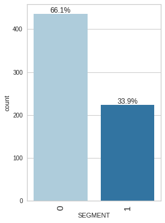

```python
#plot counts for each segment
labeled_barplot(ALB_scaled_k2_df, "SEGMENT", perc=True, n=None)
```

```python
# let's display cluster profiles
cluster_profile_k2.style.highlight_max(color="darkgreen", axis=0)
```

| SEGMENT | Avg_Credit_Limit | Total_Credit_Cards | Total_visits_bank | Total_visits_online | Total_calls_made |
| --- | --- | --- | --- | --- | --- |
| 0 | 46082.568807 | 5.885321 | 3.158257 | 2.119266 | 1.894495 |
| 1 | 12174.107143 | 2.410714 | 0.933036 | 3.553571 | 6.870536 |

```python
cluster_profile_k2["count_in_each_segments"] = (
    ALB_k2_df.groupby("SEGMENT")["Avg_Credit_Limit"].count().values
)
```

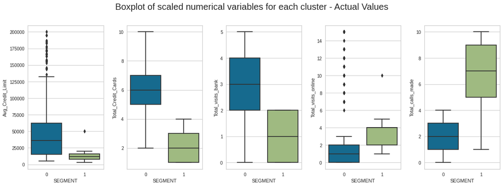

```python
#visualize the boxplots for each segment and feature
fig, axes = plt.subplots(1, 5, figsize=(16, 6))
fig.suptitle("Boxplot of scaled numerical variables for each cluster - Actual Values", fontsize=20)
counter = 0
for ii in range(5):
    sns.boxplot(
        ax=axes[ii],
        y=ALB_k2_df[num_col[counter]],
        x=ALB_k2_df["SEGMENT"],
    )
    counter = counter + 1

fig.tight_layout(pad=2.0)
```

```python
#Crosstable Total_Credit_cards per segment
pd.crosstab(ALB_k2_df.SEGMENT, ALB_k2_df.Total_Credit_Cards).style.highlight_max(
    color="darkgreen", axis=0
)
```

| Total_Credit_Cards SEGMENT | 1 | 2 | 3 | 4 | 5 | 6 | 7 | 8 | 9 | 10 |
| --- | --- | --- | --- | --- | --- | --- | --- | --- | --- | --- |
| 0 | 0 | 1 | 0 | 102 | 74 | 117 | 101 | 11 | 11 | 19 |
| 1 | 59 | 63 | 53 | 49 | 0 | 0 | 0 | 0 | 0 | 0 |

Overall the separation is good.

```python
#Crosstable Avg_Credit_Limt per segment
pd.crosstab(ALB_k2_df.Avg_Credit_Limit,ALB_k2_df.SEGMENT).style.highlight_max(
    color="darkgreen", axis=1)
```

| SEGMENT Avg_Credit_Limit | 0 | 1 |
| --- | --- | --- |
| 3000 | 0 | 1 |
| 5000 | 8 | 13 |
| 6000 | 14 | 17 |
| 7000 | 11 | 13 |
| 8000 | 15 | 20 |
| 9000 | 10 | 18 |
| 10000 | 12 | 14 |
| 11000 | 9 | 15 |
| 12000 | 10 | 8 |
| 13000 | 10 | 18 |
| 14000 | 9 | 14 |
| 15000 | 6 | 11 |
| 16000 | 9 | 13 |
| 17000 | 10 | 13 |
| 18000 | 14 | 9 |
| 19000 | 13 | 13 |
| 20000 | 7 | 13 |
| 25000 | 1 | 0 |
| 26000 | 5 | 0 |
| 27000 | 2 | 0 |
| 28000 | 3 | 0 |
| 29000 | 5 | 0 |
| 30000 | 6 | 0 |
| 31000 | 5 | 0 |
| 32000 | 2 | 0 |
| 33000 | 4 | 0 |
| 34000 | 6 | 0 |
| 35000 | 2 | 0 |
| 36000 | 11 | 0 |
| 37000 | 6 | 0 |

[output cut: 80 more lines]

```python
#Crosstable Total_Visits_bank per segment
pd.crosstab(ALB_k2_df.SEGMENT, ALB_k2_df.Total_visits_bank).style.highlight_max(
    color="darkgreen", axis=0
)
```

| Total_visits_bank SEGMENT | 0 | 1 | 2 | 3 | 4 | 5 |
| --- | --- | --- | --- | --- | --- | --- |
| 0 | 20 | 33 | 93 | 100 | 92 | 98 |
| 1 | 80 | 79 | 65 | 0 | 0 | 0 |

The separation between segment 0 and 1 good.

```python
#Crosstable Total_visits_online per segment
pd.crosstab(ALB_k2_df.SEGMENT, ALB_k2_df.Total_visits_online).style.highlight_max(
    color="darkgreen", axis=0
)
```

| Total_visits_online SEGMENT | 0 | 1 | 2 | 3 | 4 | 5 | 6 | 7 | 8 | 9 | 10 | 11 | 12 | 13 | 14 | 15 |
| --- | --- | --- | --- | --- | --- | --- | --- | --- | --- | --- | --- | --- | --- | --- | --- | --- |
| 0 | 144 | 106 | 135 | 1 | 0 | 0 | 1 | 7 | 6 | 4 | 5 | 5 | 6 | 5 | 1 | 10 |
| 1 | 0 | 3 | 54 | 43 | 69 | 54 | 0 | 0 | 0 | 0 | 1 | 0 | 0 | 0 | 0 | 0 |

Separation between Segments is not clear.

```python
#Crosstable Total_calls_made per segment
pd.crosstab(ALB_k2_df.SEGMENT, ALB_k2_df.Total_calls_made).style.highlight_max(
    color="darkgreen", axis=0
)
```

| Total_calls_made SEGMENT | 0 | 1 | 2 | 3 | 4 | 5 | 6 | 7 | 8 | 9 | 10 |
| --- | --- | --- | --- | --- | --- | --- | --- | --- | --- | --- | --- |
| 0 | 97 | 89 | 90 | 83 | 77 | 0 | 0 | 0 | 0 | 0 | 0 |
| 1 | 0 | 1 | 1 | 0 | 31 | 29 | 39 | 35 | 30 | 32 | 26 |

Separation between segments is good.

Visualization of Clusters k=2

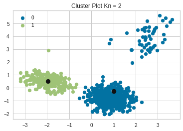

```python
#Function to visualize the clusters using pca
#PCA is done inside the visualize_clusters function (Refer to the section FUNCTIONS
#to see how this was implemented)

visualize_clusters(ALB_scaled_k2_df, 5, 2)
```

Notice that K=2 clusters is good except that there is a large group of data points that are too far from the center of the segment 0. Therefore, this doesn't look better than K=3.

Comparing K=2, K=3, K=4.

Earlier, we compared the silhouette scores and determined:

- n_clusters = 2, silhouette score = 0.41842496663215445
- n_clusters = 3, silhouette score = 0.5157182558881063
- n_clusters = 4, silhouette score = 0.3556670619372605

So n_clusters - 3 has the highest score.

**Revisit the Silhouete Visualizations for K=2,K=3,K=4.**

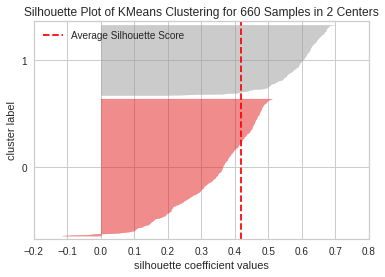

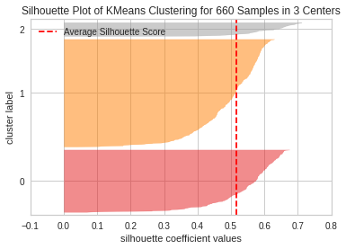

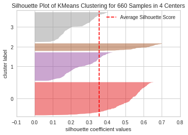

```python
#make subplots

kns = [2,3,4]

for kn in kns:
  visualizer=SilhouetteVisualizer(KMeans(kn, random_state=1))
  visualizer.fit(ALB_scaled_df)
  visualizer.show()
```

Now lets compare the K=2, K=3, and K=4 clusters.

[figure not shown]

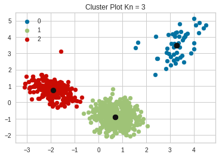

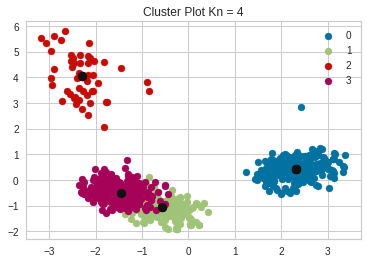

```python
#Function to visualize the clusters using pca
#PCA is done inside the visualize_clusters function (Refer to the section FUNCTIONS
#to see how this was implemented)
visualize_clusters(ALB_scaled_k2_df, 5, 2)
visualize_clusters(ALB_scaled_k3_df, 5, 3)
visualize_clusters(ALB_scaled_k4_df, 5, 4)
```

### **Conclusions for Kn means Clustering**

From the above cluster plots, we can determine that when k=3, the clustering is best.

With all the information above, we determined that for Kn means, K=3 is the best number of clusters.

## **Hierarchical Clustering**

Next we will apply Hierarchical clustering with different linkage methods, plots the corresponding dendograms for each linkage method, check the cophenetic correlations for each linkage method and determine the appropriate number of clusters.

```python
#We are going to implement the model with the following distances and linkage methods.
distance_metrics = ["euclidean","chebyshev","cityblock","mahalanobis"]
linkage_methods = ["single","complete","average","weighted"]
linkage_methods_Eu = ["ward", "centroid"]
```

### **Cophenetic** Correlation

```python
#Determine the cophenetic correlation for different distances and linkage methods
high_cophenet_corr = 0
high_dm_lm = [0, 0]

for dm in distance_metrics:
    for lm in linkage_methods:
        Z = linkage(ALB_scaled_df, metric=dm, method=lm)
        c, coph_dists = cophenet(Z, pdist(ALB_scaled_df))
        print(
            "Cophenetic correlation for {} distance and {} linkage is {}.".format(
                dm.capitalize(), lm, c
            )
        )
        if high_cophenet_corr < c:
            high_cophenet_corr = c
            high_dm_lm[0] = dm
            high_dm_lm[1] = lm
```

```
Cophenetic correlation for Euclidean distance and single linkage is 0.7391220243806552.
Cophenetic correlation for Euclidean distance and complete linkage is 0.8599730607972423.
Cophenetic correlation for Euclidean distance and average linkage is 0.8977080867389372.
Cophenetic correlation for Euclidean distance and weighted linkage is 0.8861746814895477.
Cophenetic correlation for Chebyshev distance and single linkage is 0.7382354769296767.
Cophenetic correlation for Chebyshev distance and complete linkage is 0.8533474836336782.
Cophenetic correlation for Chebyshev distance and average linkage is 0.8974159511838106.
Cophenetic correlation for Chebyshev distance and weighted linkage is 0.8913624010768603.
Cophenetic correlation for Cityblock distance and single linkage is 0.7252379350252723.
Cophenetic correlation for Cityblock distance and complete linkage is 0.8731477899179829.
Cophenetic correlation for Cityblock distance and average linkage is 0.896329431104133.
Cophenetic correlation for Cityblock distance and weighted linkage is 0.8825520731498188.
Cophenetic correlation for Mahalanobis distance and single linkage is 0.7058064784553606.
Cophenetic correlation for Mahalanobis distance and complete linkage is 0.5422791209801751.
Cophenetic correlation for Mahalanobis distance and average linkage is 0.8326994115042136.
Cophenetic correlation for Mahalanobis distance and weighted linkage is 0.7805990615142518.
```

```python
# printing the combination of distance metric and linkage method with the highest cophenetic correlation
print(
    "Highest cophenetic correlation is {}, which is obtained with {} distance and {} linkage.".format(
        high_cophenet_corr, high_dm_lm[0].capitalize(), high_dm_lm[1]
    )
)
```

```
Highest cophenetic correlation is 0.8977080867389372, which is obtained with Euclidean distance and average linkage.
```

Since Euclidean distance gave the highest Correlation, we will first focus on this distance only.

```python
# list of linkage methods
linkage_methods_Euclidean = ["single", "complete", "average", "centroid", "ward", "weighted"]

high_cophenet_corr = 0
high_dm_lm = [0, 0]

for lm in linkage_methods_Euclidean:
    Z = linkage(ALB_scaled_df, metric="euclidean", method=lm)
    c, coph_dists = cophenet(Z, pdist(ALB_scaled_df))
    print("Cophenetic correlation for {} linkage is {}.".format(lm, c))
    if high_cophenet_corr < c:
        high_cophenet_corr = c
        high_dm_lm[0] = "euclidean"
        high_dm_lm[1] = lm
```

```
Cophenetic correlation for single linkage is 0.7391220243806552.
Cophenetic correlation for complete linkage is 0.8599730607972423.
Cophenetic correlation for average linkage is 0.8977080867389372.
Cophenetic correlation for centroid linkage is 0.8939385846326323.
Cophenetic correlation for ward linkage is 0.7415156284827493.
Cophenetic correlation for weighted linkage is 0.8861746814895477.
```

```python
# printing the combination of distance metric and linkage method with the highest cophenetic correlation
print(
    "Highest cophenetic correlation is {}, which is obtained with {} linkage.".format(
        high_cophenet_corr, high_dm_lm[1]
    )
)
```

```
Highest cophenetic correlation is 0.8977080867389372, which is obtained with average linkage.
```

### **Dendrograms**

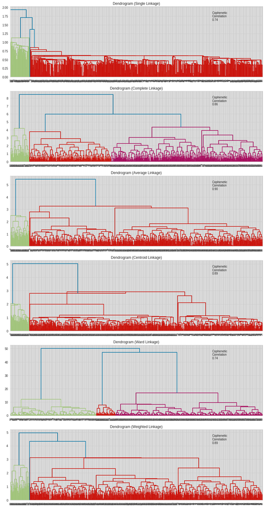

```python
# lists to save results of cophenetic correlation calculation
compare_cols = ["Linkage", "Cophenetic Coefficient"]
compare = []

# to create a subplot image
fig, axs = plt.subplots(len(linkage_methods_Euclidean), 1, figsize=(15, 30))

# We will enumerate through the list of linkage methods above
# For each linkage method, we will plot the dendrogram and calculate the cophenetic correlation
for i, method in enumerate(linkage_methods_Euclidean):
    Z = linkage(ALB_scaled_df, metric="euclidean", method=method)

    dendrogram(Z, ax=axs[i])
    axs[i].set_title(f"Dendrogram ({method.capitalize()} Linkage)")

    coph_corr, coph_dist = cophenet(Z, pdist(ALB_scaled_df))
    axs[i].annotate(
        f"Cophenetic\nCorrelation\n{coph_corr:0.2f}",
        (0.80, 0.80),
        xycoords="axes fraction",
    )

    compare.append([method, coph_corr])
```

To determine the number of clusters from the dendrograms, we locate the largest vertical difference between nodes and we draw a horizontal line in between. Then we count the number of intersecting vertical lines. This number is the number of clusters.

However, this not necessarily means that this is the optimal number of clusters because the threshold where the phenom line cuts the dendrogram is not a only-one-answer value.

Therefore we will use it with some reservation.

[Where to cut the dendrogram](https://www.displayr.com/what-is-dendrogram/)

```python
#let's create a dataframe to compare cophenetic correlations for each linkage method
#Euclidean Distance
coph_link = pd.DataFrame(compare, columns=compare_cols)
coph_link
```

|  | Linkage | Cophenetic Coefficient |
| --- | --- | --- |
| 0 | single | 0.739 |
| 1 | complete | 0.860 |
| 2 | average | 0.898 |
| 3 | centroid | 0.894 |
| 4 | ward | 0.742 |
| 5 | weighted | 0.886 |

As we found out earlier, the average euclidean method-distance had the highest cophenetic correlation. Second highest was the centroid-euclidean and then the weighted-euclidean.

**Dendrograms with phenom Line**

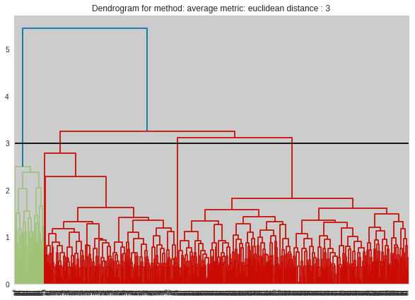

```python
#plot the dendrograms with a phenom line, from before notice distance is somewhere in betweem
#distance 5 to 3. If we choose 3:
dendrogram_single_plot(ALB_scaled_df,"average","euclidean",3)
```

If we choose the phenom line at distance = 3, then we obtain 4 clusters.

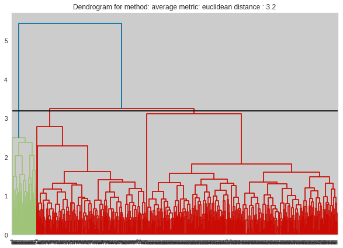

```python
#plot the dendrograms with a phenom line, from before notice distance is somewhere in betweem
#distance 5 to 3. If we choose 3.2:
dendrogram_single_plot(ALB_scaled_df,"average","euclidean",3.2)
```

In the case above, the number of clusters is 3.

So from the above it is clear that a dendrogram can only give us an idea of what the optimal number of clusters should be.

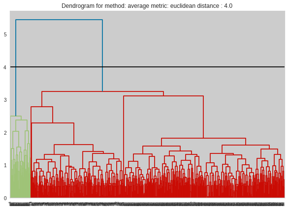

```python
#plot the dendrograms with a phenom line, from before notice distance is somewhere in betweem
#distance 5 to 3. If we choose 4.0:
dendrogram_single_plot(ALB_scaled_df,"average","euclidean",4.0)
```

If we chose the distance to be 4, the number of clusters would be 2.

So what is the optimal number of clusters considering the Average-Euclidean method-distance?

From the plots above we can see that somewhere between 2 and up to 5 clusters.

Lets plot the other dendrograms for the other methods with Euclidean distance.

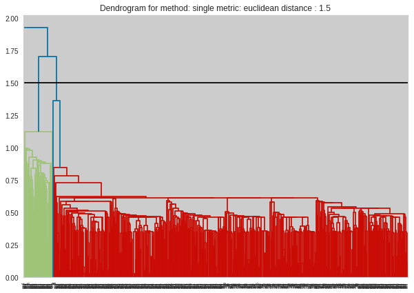

```python
#plot dendrogram with phenom line for Single Euclidean, from before notice distance is somewhere
#between 2 and 1.15,
dendrogram_single_plot(ALB_scaled_df,"single","euclidean",1.5)
```

The phenom line determines that the optimal number of clusters is 3.

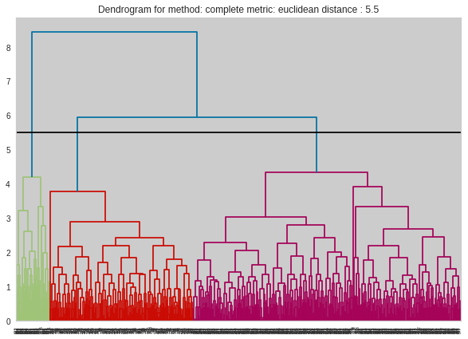

```python
#plot dendrogram with phenom line for Complete Euclidean, from before notice distance lets consider
#distance to be 5.5
dendrogram_single_plot(ALB_scaled_df,"complete","euclidean",5.5)
```

If we picked the distance to be 5.5 we would note 3 clusters.

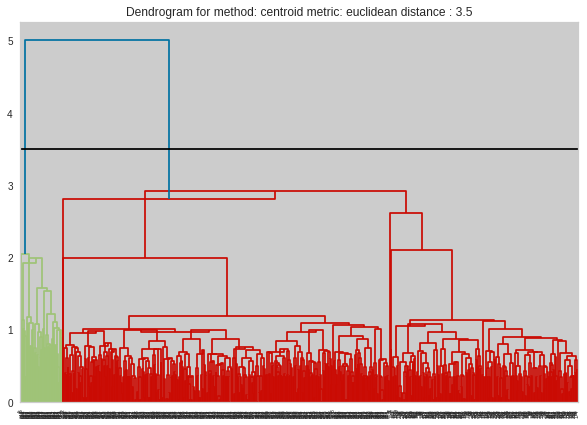

```python
#plot dendrogram with phenom line for Centroid Euclidean, from before notice distance
#lets take 3.5
dendrogram_single_plot(ALB_scaled_df,"centroid","euclidean",3.5)
```

When we chose the distance to be 3.5, the centroid-Euclidean method-distance resulted in 2 clusters.

The number of clusters could have also fluctuated between 2 to 5.

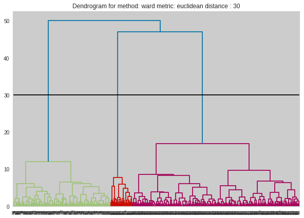

```python
#plot dendrogram with phenom line for Ward Euclidean, from before notice distance
#lets consider 30
dendrogram_single_plot(ALB_scaled_df,"ward","euclidean",30)
```

When we chose the distance to be 30, we noted 3 clusters.

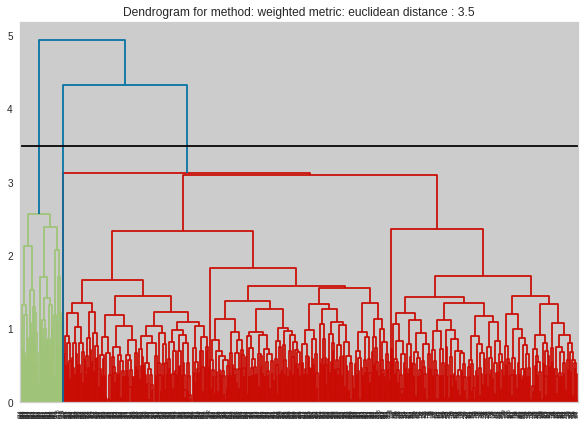

```python
#plot dendrogram with phenom line for Weighted Euclidean, from before notice distance
#lets consider distance 3.5
dendrogram_single_plot(ALB_scaled_df,"weighted","euclidean",3.5)
```

When we chose distance to be 3.5 we noted 3 clusters.

We already knew that the highest cophenetic correlation value was obtained with Euclidean-average distance-method.

The highest was cophenetic correlation value was given by Euclidean Average.

1. Cophenetic correlation for Euclidean distance and average linkage is 0.8977080867389372.

Then it was these methods-distances:

We already saw the Euclidean distance with all methods. Now lets take a look at the next 3 methods-distances because they are around 0.89xx value, close to what was obtained with the average Euclidean method:

- Cityblock-Average
- Chebyshev-Average
- Euclidean-Centroid (already seen above)

Also notice that Mahalanobis distance gave the lowest cophenetic correlation values.

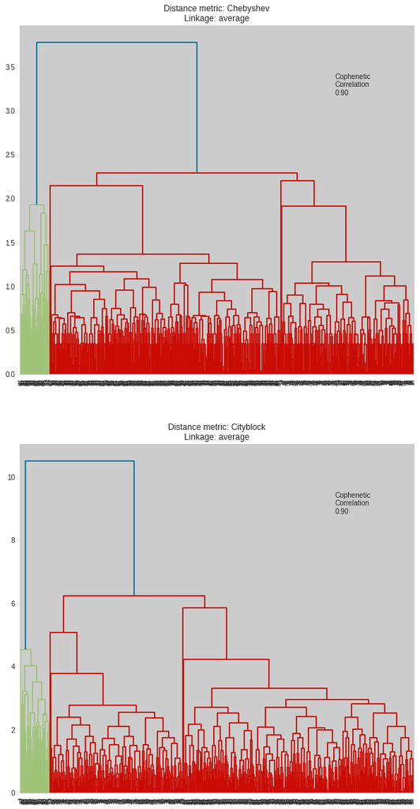

```python
# list of distance metrics
distance_metrics = ["chebyshev", "cityblock"]

# list of linkage methods
linkage_methods = ["average"]

# to create a subplot image
fig, axs = plt.subplots(
    len(distance_metrics), figsize=(10, 20)
)

i = 0
for dm in distance_metrics:
    for lm in linkage_methods:
        Z = linkage(ALB_scaled_df, metric=dm, method=lm)

        dendrogram(Z, ax=axs[i])
        axs[i].set_title("Distance metric: {}\nLinkage: {}".format(dm.capitalize(), lm))

        coph_corr, coph_dist = cophenet(Z, pdist(ALB_scaled_df))
        axs[i].annotate(
            f"Cophenetic\nCorrelation\n{coph_corr:0.2f}",
            (0.80, 0.80),
            xycoords="axes fraction",
        )
        i += 1
```

Next we run phenom lines in the above distance-method dendrograms.

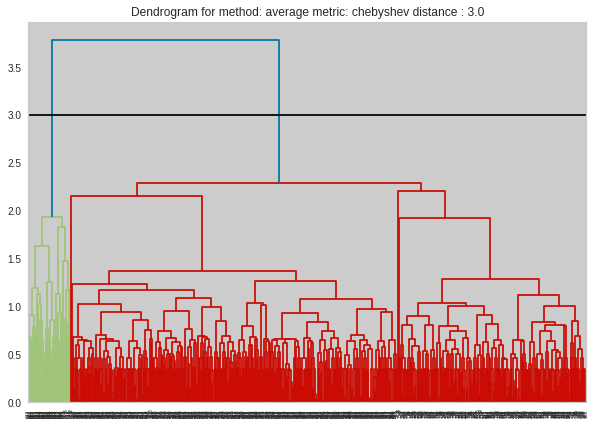

```python
#plot dendrogram with phenom line for Chebyshev Average, from before notice distance
#lets consider distance 3
dendrogram_single_plot(ALB_scaled_df,"average","chebyshev",3.0)
```

From the above plot we consider clusters = 2.

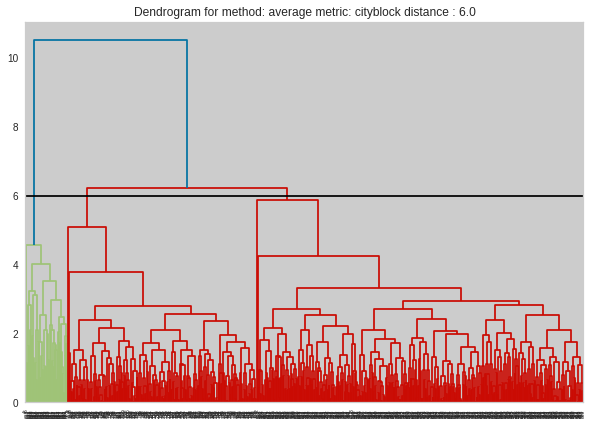

```python
#plot dendrogram with phenom line for citiblock Average, from before notice distance
#lets consider distance 6
dendrogram_single_plot(ALB_scaled_df,"average","cityblock",6.0)
```

From the above plot if we chose distance to be 6, we note 3 clusters.

### **Model Euclidean-Average**

Linkage: {'average'}

uses the average of the distances of each observation of the two sets.

We choose clusters = 3.

```python
#copy dataframes for Hiearchical Clustering
ALB_hc_scaled_df = ALB_scaled_df.copy()
ALB_hc_df = ALB_df.copy()
```

```python
HCmodel = AgglomerativeClustering(n_clusters=3, affinity="euclidean", linkage="average")
HCmodel.fit(ALB_scaled_df)
```

```
AgglomerativeClustering(affinity='euclidean', linkage='average', n_clusters=3)
```

```python
# adding hierarchical cluster labels to the original and scaled dataframes
ALB_hc_scaled_df["SEGMENT"] = HCmodel.labels_
ALB_hc_df["SEGMENT"] = HCmodel.labels_
```

**Cluster Profiling**

```python
cluster_profile_avg = ALB_hc_df.groupby("SEGMENT").mean()
```

```python
cluster_profile_avg["segment_count"] = (
    ALB_hc_df.groupby("SEGMENT")["Avg_Credit_Limit"].count().values
)
```

```python
# let's display cluster profiles
cluster_profile_avg.style.highlight_max(color="darkgreen", axis=0)
```

| SEGMENT | Avg_Credit_Limit | Total_Credit_Cards | Total_visits_bank | Total_visits_online | Total_calls_made | segment_count |
| --- | --- | --- | --- | --- | --- | --- |
| 0 | 33713.178295 | 5.511628 | 3.485788 | 0.984496 | 2.005168 | 387 |
| 1 | 141040.000000 | 8.740000 | 0.600000 | 10.900000 | 1.080000 | 50 |
| 2 | 12197.309417 | 2.403587 | 0.928251 | 3.560538 | 6.883408 | 223 |

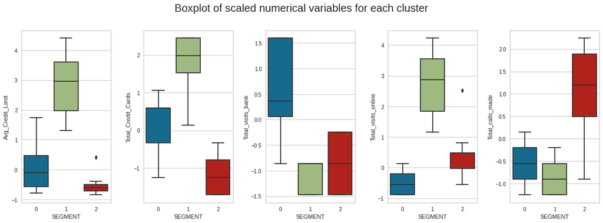

```python
fig, axes = plt.subplots(1, 5, figsize=(16, 6))
fig.suptitle("Boxplot of scaled numerical variables for each cluster", fontsize=20)
counter = 0
for ii in range(5):
    sns.boxplot(
        ax=axes[ii],
        y=ALB_hc_scaled_df[num_col[counter]],
        x=ALB_hc_scaled_df["SEGMENT"],
    )
    counter = counter + 1

fig.tight_layout(pad=2.0)
```

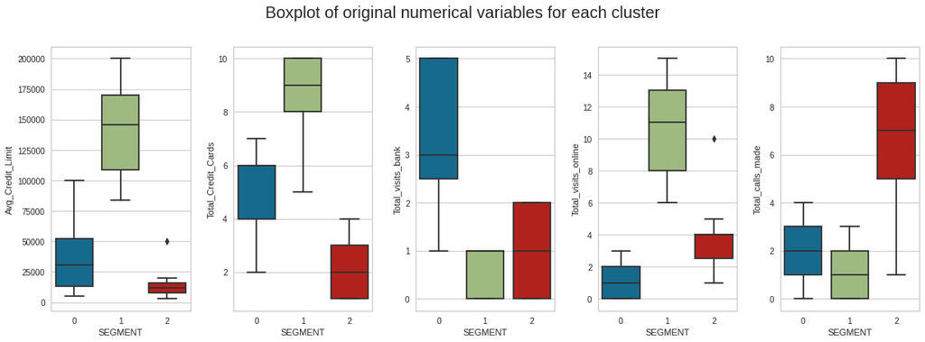

```python
fig, axes = plt.subplots(1, 5, figsize=(16, 6))
fig.suptitle("Boxplot of original numerical variables for each cluster", fontsize=20)
counter = 0
for ii in range(5):
    sns.boxplot(ax=axes[ii], y=ALB_hc_df[num_col[counter]], x=ALB_hc_df["SEGMENT"])
    counter = counter + 1

fig.tight_layout(pad=2.0)
```

Notice that Total_Credit_Cards and Total_visits_online are well separated.

Total_calls_made segment 0 and 1 is not separated well, and neither is segment 1 and 2 for Total_values_bank.

Avg_Credit_Limit is well separated for Segment 0 and 1 but not for 2.

Visualize the Clusters

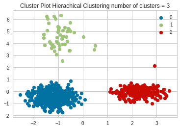

```python
visualize_hc_clusters(ALB_hc_scaled_df,5,3)
```

Clusters equal to 3 performed well.

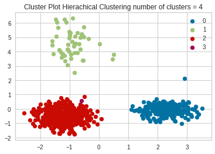

```python
visualize_hc_clusters(ALB_hc_scaled_df,5,4)
```

Clusters equal to 4 didn't perform well.

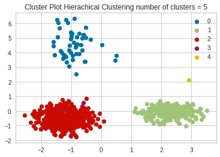

```python
visualize_hc_clusters(ALB_hc_scaled_df,5,5)
```

Clusters equal to 5 didn't perform well.

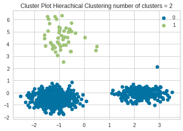

```python
visualize_hc_clusters(ALB_hc_scaled_df,5,2)
```

clusters equal to 2 didn't perform well at all.

**Summarizing Hierarchical Clustering**

```python
cc= [[1,'Euclidean','average',0.8977080867389372],
           [2,'Cityblock','average',0.896329431104133],
           [3,'Chebyshev','average',0.8974159511838106],
           [4,'Euclidean','centroid',0.8939385846326323]]

cc_df = pd.DataFrame(cc,columns=['Ranking','Distance','Method','Cophenetic_Value'])
cc_df
```

[output not shown]

**Revisiting our previous dendrograms for HC**

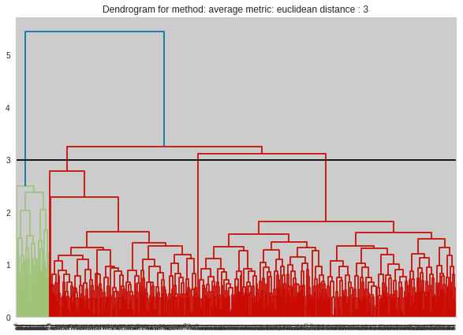

```python
#plot the dendrograms with a phenom line, from before notice distance is somewhere in betweem
#distance 5 to 3. If we choose 3:
dendrogram_single_plot(ALB_scaled_df,"average","euclidean",3)
```

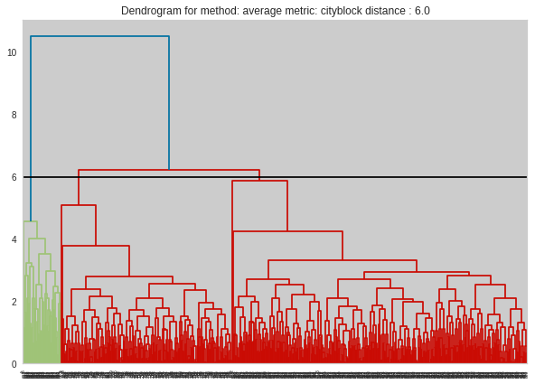

```python
#plot dendrogram with phenom line for citiblock Average, from before notice distance
#lets consider distance 6
dendrogram_single_plot(ALB_scaled_df,"average","cityblock",6.0)
```

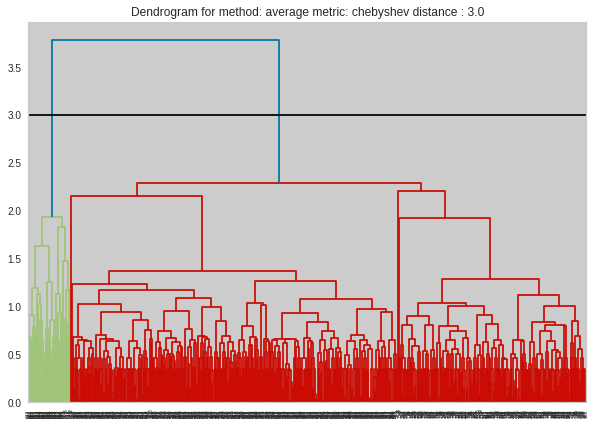

```python
#plot dendrogram with phenom line for Chebyshev Average, from before notice distance
#lets consider distance 3
dendrogram_single_plot(ALB_scaled_df,"average","chebyshev",3.0)
```

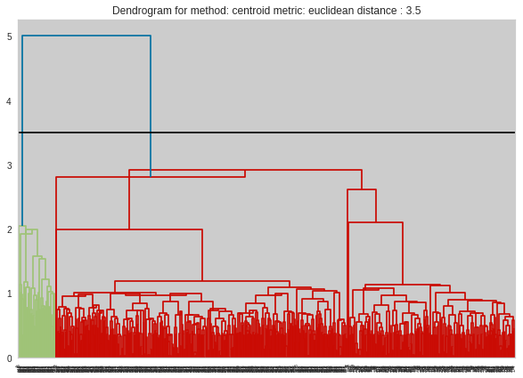

```python
#plot dendrogram with phenom line for Centroid Euclidean, from before notice distance
#lets take 3.5
dendrogram_single_plot(ALB_scaled_df,"centroid","euclidean",3.5)
```

We determined that for the top 3 distance-methods, cluster = 3 is within the possible values.

We also visualized the clusters and determined that 3 clusters works the best.

So in conclusion, the Hierarchical Clustering worked best with Average linkage method, Euclidean method and 3 clusters.

## **Comparing Kn vs Hierarchical Results**

We cam compare how clustering worked in both cases.

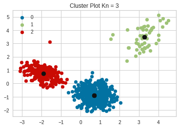

```python
visualize_clusters(ALB_scaled_k3_df, 5, 3)
```

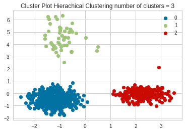

```python
visualize_hc_clusters(ALB_hc_scaled_df,5,3)
```

Note that athe clustering that both methods perform similarly well.

### **Compare Profiles**

**Kn means Clustering**

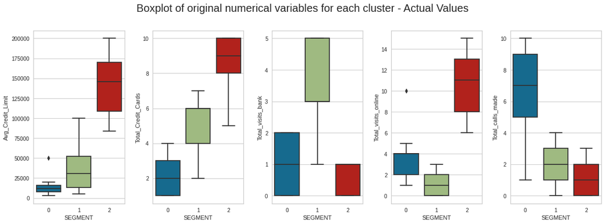

```python
#visualize the boxplots for each segment for each feature for the data represented
#with actual values.
fig, axes = plt.subplots(1, 5, figsize=(16, 6))
fig.suptitle("Boxplot of original numerical variables for each cluster - Actual Values", fontsize=20)
counter = 0
for ii in range(5):
    sns.boxplot(ax=axes[ii], y=ALB_k3_df[num_col[counter]], x=ALB_k3_df["SEGMENT"])
    counter = counter + 1

fig.tight_layout(pad=2.0)
```

```python
# let's display cluster profiles
cluster_profile_k3.style.highlight_max(color="darkgreen", axis=0)
```

| SEGMENT | Avg_Credit_Limit | Total_Credit_Cards | Total_visits_bank | Total_visits_online | Total_calls_made | count_in_each_segments |
| --- | --- | --- | --- | --- | --- | --- |
| 0 | 12174.107143 | 2.410714 | 0.933036 | 3.553571 | 6.870536 | 224 |
| 1 | 33782.383420 | 5.515544 | 3.489637 | 0.981865 | 2.000000 | 386 |
| 2 | 141040.000000 | 8.740000 | 0.600000 | 10.900000 | 1.080000 | 50 |

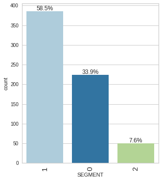

```python
#plot counts for each segment
labeled_barplot(ALB_scaled_k3_df, "SEGMENT", perc=True, n=None)
```

**HC Clustering**

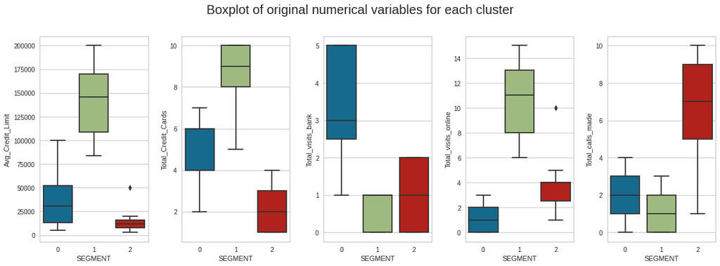

```python
fig, axes = plt.subplots(1, 5, figsize=(16, 6))
fig.suptitle("Boxplot of original numerical variables for each cluster", fontsize=20)
counter = 0
for ii in range(5):
    sns.boxplot(ax=axes[ii], y=ALB_hc_df[num_col[counter]], x=ALB_hc_df["SEGMENT"])
    counter = counter + 1

fig.tight_layout(pad=2.0)
```

```python
# let's display cluster profiles
cluster_profile_avg.style.highlight_max(color="darkgreen", axis=0)
```

| SEGMENT | Avg_Credit_Limit | Total_Credit_Cards | Total_visits_bank | Total_visits_online | Total_calls_made | segment_count |
| --- | --- | --- | --- | --- | --- | --- |
| 0 | 33713.178295 | 5.511628 | 3.485788 | 0.984496 | 2.005168 | 387 |
| 1 | 141040.000000 | 8.740000 | 0.600000 | 10.900000 | 1.080000 | 50 |
| 2 | 12197.309417 | 2.403587 | 0.928251 | 3.560538 | 6.883408 | 223 |

Notice that actually there are no noticeable differences between KN and HC clustering. The segments labels may be different but the clustering is very similar.

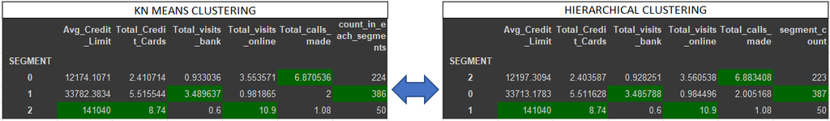

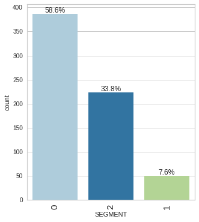

```python
#plot counts for each segment
labeled_barplot(ALB_hc_scaled_df, "SEGMENT", perc=True, n=None)
```

Notice that both Kn and HC cluster the dataset almost identically. There are only a slight difference between them.

### **Clustered Data Analysis**

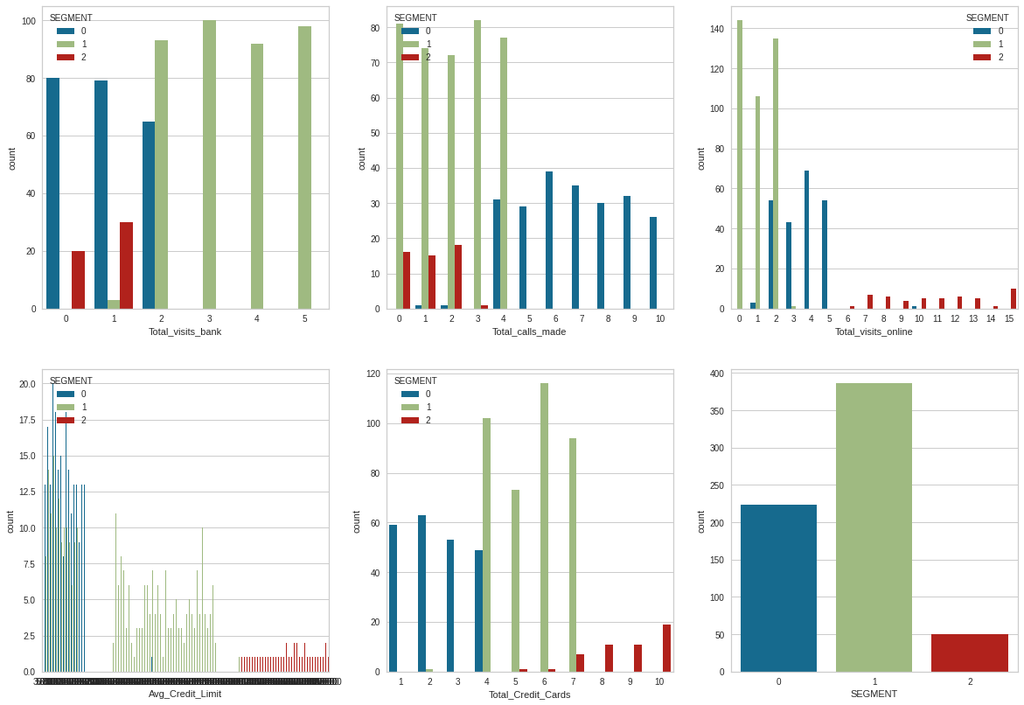

```python
fig, axes = plt.subplots(2, 3, figsize=(20,14))

sns.countplot(data=ALB_k3_df, x="Total_visits_bank", hue="SEGMENT", ax=axes[0,0])
sns.countplot(data=ALB_k3_df, x="Total_calls_made", hue="SEGMENT", ax=axes[0,1])
sns.countplot(data=ALB_k3_df, x="Total_visits_online", hue="SEGMENT", ax=axes[0,2])
sns.countplot(data=ALB_k3_df, x="Avg_Credit_Limit", hue="SEGMENT",ax=axes[1,0])
sns.countplot(data=ALB_k3_df, x="Total_Credit_Cards", hue="SEGMENT",ax=axes[1,1])
sns.countplot(data = ALB_k3_df, x="SEGMENT", ax=axes[1,2])
```

[figure not shown]

```python
#calculate the average credit limit per card.
ALB_S0_df = ALB_k3_df[ALB_k3_df['SEGMENT']==0]
ALB_S1_df = ALB_k3_df[ALB_k3_df['SEGMENT']==1]
ALB_S2_df = ALB_k3_df[ALB_k3_df['SEGMENT']==2]

#for credit limit
ACCL_S0 = ALB_S0_df['Avg_Credit_Limit'].sum()/ALB_S0_df['Total_Credit_Cards'].sum()
ACCL_S1 = ALB_S1_df['Avg_Credit_Limit'].sum()/ALB_S1_df['Total_Credit_Cards'].sum()
ACCL_S2 = ALB_S2_df['Avg_Credit_Limit'].sum()/ALB_S2_df['Total_Credit_Cards'].sum()

#for online
AOV_S0 = ALB_S0_df['Total_visits_online'].sum()/ALB_S0_df['Total_Credit_Cards'].sum()
AOV_S1 = ALB_S1_df['Total_visits_online'].sum()/ALB_S1_df['Total_Credit_Cards'].sum()
AOV_S2 = ALB_S2_df['Total_visits_online'].sum()/ALB_S2_df['Total_Credit_Cards'].sum()

#for bank visits
ABV_S0 = ALB_S0_df['Total_visits_bank'].sum()/ALB_S0_df['Total_Credit_Cards'].sum()
ABV_S1 = ALB_S1_df['Total_visits_bank'].sum()/ALB_S1_df['Total_Credit_Cards'].sum()
ABV_S2 = ALB_S2_df['Total_visits_bank'].sum()/ALB_S2_df['Total_Credit_Cards'].sum()

#for calls
ACM_S0 = ALB_S0_df['Total_calls_made'].sum()/ALB_S0_df['Total_Credit_Cards'].sum()
ACM_S1 = ALB_S1_df['Total_calls_made'].sum()/ALB_S1_df['Total_Credit_Cards'].sum()
ACM_S2 = ALB_S2_df['Total_calls_made'].sum()/ALB_S2_df['Total_Credit_Cards'].sum()




accl_k3 = [[0,ACCL_S0, AOV_S0, ABV_S0, ACM_S0],[1,ACCL_S1,AOV_S1, ABV_S1, ACM_S1],
           [2,ACCL_S2,AOV_S2, ABV_S2, ACM_S2]]
accl_k3_df = pd.DataFrame(accl_k3,columns=['SEGMENT','Avg Credit pc',
                                           'Avg Online Visit pc',
                                           'Avg Bank Visit pc',
                                           'Avg Call Made pc'])


accl_k3_df
```

|  | SEGMENT | Avg Credit pc | Avg Online Visit pc | Avg Bank Visit pc | Avg Call Made pc |
| --- | --- | --- | --- | --- | --- |
| 0 | 0 | 5050.000 | 1.474 | 0.387 | 2.850 |
| 1 | 1 | 6124.941 | 0.178 | 0.633 | 0.363 |
| 2 | 2 | 16137.300 | 1.247 | 0.069 | 0.124 |

## **Conclusions, Insights, Takeaways**

1. ALB should classify its customers into 3 segments, namely SuperVIP (Segment 2), VIP (Segment 1), and Standard (segment 0). The names can change according to the Marketing Department plan. However, the idea is that SuperVIP are more exclusive customers, and VIP are most common customers.
2. The largest segment is the VIP segment-1 with 59% of all customers, followed by the Standard-0 segment with 34%. The SuperVIP-2 segment only has 7.6% of all customers.

**Customer Characteristics per segment**

**Customer Characteristics per segment per Card**

1. VIP-1 credit cards consistently have the more problems, inquiries, issues with their products, to the point that they average 0.63 visits to the bank per credit card. This is almost twice as many visits a Standard-0 credit card makes and about 10 times more the visits a SuperVip-2 credit card makes to the bank. The VIP-1 credit card makes the least online visits - roughly 12% of the visits compared to a Standard-0 credit card and 14% when compared to a SuperVIP-2.
2. Standard-0 credit cards make less visits to the bank than VIP-1 credit cards (roughly 40% less), but significantly more than SuperVIP-2 cards. The standard-0 credit cards are the ones that make more online visits and also the ones that make the most phone calls.
3. SuperVIP-2 cards make the least calls, the least visits and less online visits than the Standard-0 card.

This is the ranking of the Troublesome Bank Visit

From Most to Least

1. VIP-1
2. Standard-0
3. SuperVIP-2

This is the ranking of the Also Troublesome Phone Call to the bank

From Most to Least

1. Standard-0
2. VIP-1
3. SuperVIP-2

This is the ranking of the most convenient Online visit:

From Most to least

1. Standard-0
2. SuperVIP-2
3. VIP-1

## **Insights**

II. The Standard-0 customer visits online often, and more than any other segment, but also makes significantly more calls than anyone. This may be an indication that he/she cannot have his or her issues/inquiries solved online, particularly of interest is that a card produces more phone calls than online visits.

Earlier in our bivariate analysis we also observed these interesting details:

- Total_Credit_Cards and Total_visits_online have a correlation of 0.17, among the lowest between all features. So this may mean that without regards of the Total number of credit cards, online communications may not be trusted, or may not be working, or may not provide the service customers require.

-Total_visits_online and Total_visits_bank is surprisingly high, with a correlation of 0.55. This may mean that customers that have a high number of online visits end up visiting the bank for whatever reasons, probably because their issue, problem, transaction, etc couldn't be completed online.

With the above insights we conclude that:

- Segment-1 (VIP-1) experience the most incoveniences.
- Segment-1 (VIP-1) are not heavy Internet users
- Segment-1 (VIP-1) may be more traditional, old-fashioned customers.
- Segment-0 (Std-0) are heavy internet users.
- Segment-0 (Std-0) may be younger, milenials customers
- Segment-0 (Std-0) make more phone calls than visit online.
- Segment-0 (Std-0) issues are not often solved online, thus they make more calls than anyone else.
- Segment-2 (SuperVip-2) manage their cards online, do not visit the bank and try not to make phone calls.

## **Recommendations**

1. To improve customer satisfaction, focus first on Segment-1. Promote the use of the online platform within this segment. Make the access to the online banking more user friendly and implement brochures to distribute to this segment on how to access the online platform. Also promote the advantages and security of using the online platform.
2. Discourage the bank visits. Rather than penalizing customers that visit the bank by charging fees, promote online banking by offering discounts or a award point system for using the online platform.
3. Implement and/or improve intelligent chat bots on the online platform so customers can have their questions answered.
4. Then focus on Segment-0. Focus on expanding online services and if an online bot does not work well, have a larger team of human operators that can chat with the customers, with the objective of solving issues online and avoid the customer having to make a phone call.
5. To expand services, focus mostly on Segment-0 because this is the group with the least amount of services per head. Diversify credit services to this segment first.
6. To attract new customers, improve online banking services first. You do not want new customers that will joing the unhappy segment. However, to expand outside customers, focus on customers that can have overall high credit limit and that are interested in having many credit services. This is because this type of customer is consistently the one that doesn't want to go the bank, doesn't want to make calls, and solves most issues - somehow - online.

## **Useful data**

- More data like Age of the customer, Gender, and Income would be very useful for classifying customers correctly.
- Background on the limitations of the Online platform would be very useful to understand why the customer opts for not using the online platform.
- Average time a phone call lasts, average waiting time and service time, a customer spends at the bank would be very useful.
- Time of the day, the customer connects to the bank online or makes a phone call.
- The type of issues the customer calls, visits the bank for, or connects online.

-- Thank You ---